# Comoto Descriptives

Malia Crane

8/21/2021

### Overview of Received Dataset

The dataset consists of a total of 406,829 rows associated with sales transactions captured along 10 variables.

Every observed variable consisted of complete cases with no missing data.

## Audit of Variables

### Channel

A total of 6 different marketing source channels are captured with this column, and which comprise 69,016 unique sales orders.

Table 1-A: Channel Counts

| Channel | Row Count | % | Sales Orders Count | Sales Order % |
| --- | --- | --- | --- | --- |
| Display | 3,970 | 00.98% | 2,237 | 03.24% |
| Email | 36,576 | 08.99% | 10,712 | 15.52% |
| Mailing | 20,361 | 05.00% | 7,763 | 11.25% |
| Organic Social | 121,971 | 29.98% | 16,476 | 23.87% |
| SEO | 81,946 | 20.14% | 14,765 | 21.44% |
| Store | 142,005 | 34.91% | 17,033 | 24.68% |

### SalesOrder

A total of 20,665 unique sales orders were identified, 2,813 (13.61%) of which begin with the prefix character ‘C’- seemingly associated with compensatory, refund, or expense transactions having negative sales values.

The following table summarizes these C-Prefix orders by source channel:

Table 1-B: C-Prefix Sales Orders by Source Channel[^1]

| Channel | Sum of Sales | Number of Sales Orders |
| --- | --- | --- |
| Display | -1,677.21 | 41 |
| Mailing | -21,448.96 | 271 |
| Email | -49.046.86 | 437 |
| SEO | -213,777.39 | 905 |
| Organic Social | -324,196.59 | 1,184 |
| Store | -707,625.59 | 1,353 |

Sales orders without this prefix totaled 17,852 (86.39%) sales orders having positive sales values, with 6 orders having total sales values of zero.

Table 1-C: Non-C-Prefix Sales Orders by Source Channel[^2]

| Channel | Sum of Sales | Number of Sales Orders |
| --- | --- | --- |
| Display | 141,388.43 | 2,196 |
| Mailing | 567,320.21 | 7,492 |
| Email | 1,553,915.40 | 10,275 |
| Organic Social | 2,481,832.47 | 15,292 |
| SEO | 7,859,744.17 | 13,890 |
| Store | 15,978,984.97 | 15,680 |

### SKU

A total of 3,610 unique SKU’s were identified, including 8 special SKU’s (below) consisting of characters which imply adjustments, fee tracking, postage, or other process transations outside of sales figures.

Table 1-D: Unusual SKU’s

| SKU | Rows | % of Subset | Total of Sales |
| --- | --- | --- | --- |
| POST | 1162 | 61.00% | 205,640.10 |
| M | 462 | 24.30% | -175,860.34 |
| C2 | 149 | 07.80% | 20,933.00 |
| D | 86 | 04.50% | -13,220.09 |
| CRUK | 19 | 01.00% | -54,069.55 |
| DOT | 16 | 00.80% | 101,333.35 |
| BANK CHARGES | 9 | 00.50% | 465.00 |
| PADS | 2 | 00.10% | 0 |

### UnitPrice

Per-Unit prices varied from 38,970 to 0, having a median unit price of 1.95. No other unusual characteristics are noted.

### CustomerID

A total of 4,325 unique ID’s were identified. Notably, customer #14646 is associated with the highest sum of Sales (1,102,131). Customer ID effects on Sales are summarized in the Sales Section.

### State

A total of 49 US States were identified with California being the largest represented group.

### InvoiceDay

Data comprises a temporal interval of 374 days from 01/12/2010 to 09/12/2011, which can be grouped to result in 4 full 90 day time series groups. A 5th group comprised of the ‘most recent’ 90 days from the last date in the file was also created.

*The wording of the second question (Sections:2) could be taken a few different ways, and to complete those possibilities I’ve created a 5th category to demonstrate a rolling window example. This 5th group can’t be used in the time series forecast and is only mentioned here.*

| Group | From | To | Interval |
| --- | --- | --- | --- |
| 1 | 11/30/2010 | 02/28/2011 | 90 |
| 2 | 02/28/2011 | 05/29/2011 | 90 |
| 3 | 05/29/2011 | 08/27/2011 | 90 |
| 4 | 08/27/2011 | 11/25/2011 | 90 |
| 5 | 09/09/2011 | 12/8/2011 | 90 |

### Sales

Sales ranged from -127,788.96 to 127,788.96, the identical high/low values highlight that excluding C-Prefixed sales orders, which indicate refunds/expenses, should be excluded.

When excluding these entries, Sales ranged from 0 to 127,788.96 with a median of 22.46. Grouping data by Sales Orders indicated a median total order value of 34.8, while grouping by CustomerID gives a median customer sale value of 32.5 for the period.

The median for total sales by customer indicate a point estimate for each customer’s total sales contribution being 2,291.95 (i.e. During the data’s period, a single customer can be expected to purchase 2.2k on average).

### Quantity

Quantities ordered possessed a median of 9 items per row, when grouping by Sales Order a median of 21.65 items per order, and when grouped by Customer a median of 15 items total are purchased during the period.

### Item Description

A total of 3,791 unique item descriptions were found, which differed by 181 from the count of unique SKUs, indicating a small degree of divergence from the larger pattern of each SKU representing a unique item.

Using item descriptions, an attempt using topic modelling with Latent Dirichlet Allocation (LDA) was carried out. Results were not well classified in either subjective examination or item similarity scores, and are presented only as a record of the attempt.

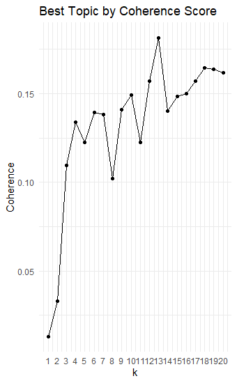

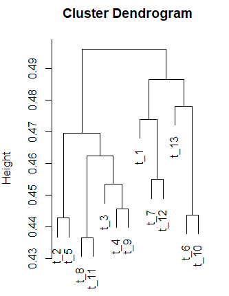

Coherence scores shown above suggested 13 topic areas. As seen below, these outputted topic areas were a poor fit for classifying items due to the inconsistent grouping choices of the top 5 entries for each area.

```
##   Topic1        Topic2     Topic3  Topic4   Topic5     Topic6   Topic7  Topic8
## 1 candle           red      metal     bag     blue  christmas   design     set
## 2 flower     retrospot       sign vintage    white       pink    black    pack
## 3   wall red_retrospot metal_sign     box polkadot decoration necklace    cake
## 4 silver          rose    garland    gift     pink       tree     home   cases
## 5    art          wrap      paper    gold      red       star    clock cutlery
##     Topic9 Topic10       Topic11  Topic12      Topic13
## 1      box    pink           set bracelet        light
## 2    purse   heart       cushion    glass       holder
## 3     tube    card cushion_cover     ring light_holder
## 4    cover    love         cover necklace        heart
## 5 birthday     tea           tin    black        glass
```

[^1]: Table 1-B: It should be noted that the Standard Deviation of Sales amounts generally increase as Sales increase, but that the variance is notably higher for Organic Social and Store Channels- an effect of the presence of negative sales values in these channels.
[^2]: Table 1-C: Standard Deviation of Sales amounts is notably higher for Organic Social (indicating highly variable sales totals), and notable lower for SEO channels (indicating unusually regular sales totals).